# Interpreting CONCORD latent with gradient-based attribution

### Examine CONCORD latent

You can plot a heatmap of CONCORD latent with example code below.

```python
import numpy as np
show_basis = 'Concord'
ncells = 1000 # downsample to 1000 cells for faster visualization
adata_ds = adata.copy()[np.random.choice(adata.n_obs, ncells, replace=False), :]
ccd.pl.heatmap_with_annotations(adata_ds, val=show_basis, transpose=True, obs_keys=['cell_type'],
                             cmap='viridis', vmin=None, vmax=None,
                             cluster_rows=True, cluster_cols=True, add_color_legend=True,
                             value_annot=False, title=None, title_fontsize=8, annot_fontsize=8,
                             yticklabels=False, xticklabels=False,
                             use_clustermap=True,
                             cluster_method='ward',
                             cluster_metric='cosine',
                             rasterize=True,
                             ax=None,
                             figsize=(8,4),
                             dpi=600, show=True, save_path=save_dir / f"heatmap_latent.pdf")
```

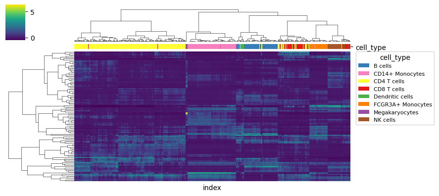

We can observe a clear block structure in the latent space. To attribute which input features (genes) drive the activation of specific latent neurons, we first need to define the **context**. A context can be a single cell or a broader group such as a cell type—but it should not encompass all cells in the dataset, since attribution requires a localized reference.

For each context, we determine which neurons are most strongly activated. One systematic way to do this is to use clustering results, which group cells into biologically meaningful contexts and reveal their characteristic activation patterns. In the example below, we take a simpler approach: for each cell type, we select the top two most highly activated neurons. Our goal is then to explain which genes are responsible for driving those neurons’ activation within the chosen context.

```python
import numpy as np
import pandas as pd
import matplotlib.pyplot as plt
import seaborn as sns

cts = adata.obs['cell_type']
Z = np.asarray(adata.obsm['Concord'])  # (n_cells, n_dims)

# Dims x cell_types mean matrix
means = (
    pd.DataFrame(Z, index=adata.obs.index)
    .groupby(cts, observed=True).mean()  # Mean per cell_type
    .T  # Dims x cell_types
    .reindex(columns=cts.cat.categories)  # Keep category order
)

# Compute top_dims dict
N = 2
top_dims = {
    ct: means[ct].nlargest(N).index.tolist()
    for ct in means.columns[means.notna().any(axis=0)]  # Skip empty categories
}

# Print results
print("Top activated latent dimensions per cell type:")
for ct, dims in top_dims.items():
    print(f"{ct}: {dims}")

# Take top-N dims per cell type, unioned in order of first appearance (for heatmap)
keep, seen = [], set()
for ct in means.columns[means.notna().any(axis=0)]:
    for d in top_dims[ct]:  # Now uses the dict
        if d not in seen:
            keep.append(d)
            seen.add(d)

top_means = means.loc[keep]

plt.figure(figsize=(4, 5))
ax = sns.heatmap(top_means, cmap='RdBu_r', cbar_kws={'label': 'Mean activation'})
ax.set_xlabel('Cell type')
ax.set_ylabel('Embedding dimension')
ax.set_title('Top activated embedding dims per cell type')
plt.tight_layout()
plt.show()
```

```
Top activated latent dimensions per cell type:
CD4 T cells: [50, 86]
CD14+ Monocytes: [89, 68]
B cells: [14, 68]
CD8 T cells: [45, 38]
NK cells: [26, 12]
FCGR3A+ Monocytes: [12, 96]
Dendritic cells: [96, 68]
Megakaryocytes: [83, 90]
```

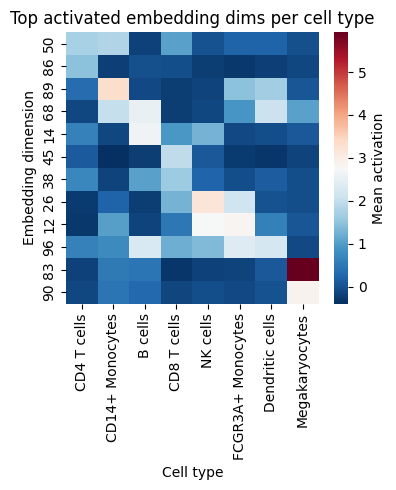